# County Recommender System

### Johnny Lin, Tommy Yu, Matthew Champagne, Laila Bahman

### PSTAT 134 S25

# Introduction

With such a large variety of locations in the US, it can be difficult to decide on the best location to start a new life after moving out. Some people look for a new location with qualities similar to their old home, seeking a sense of familiarty. Others may be looking for a place that has specific qualities that they've picked out. Either way, with over 3,000 counties in the US, it's almost impossible to research each one to find out if they might be a good pick.

With our project, we aim to create a tool to help with this problem. We will implement county recommender systems based on multiple socioeconomic and demographic indicators. By combining datasets from government and open data sources, we identify counties that best match user preferences across various quality-of-life dimensions. The factors we will use are:

- Population density
- Poverty percentage
- Education level
- Unemployment
- Median income
- Average temperature
- Average precipitation
- Crime rate
- Walkability

We will implement two recommender systems: one will find the counties that are most similar to an inputted county, and the second will allow the user to pick out specific qualities they want in a county based on a survey. Our recommender systems will then display the five most relevant counties.

# Methods

## Gathering Data

In order to rank counties with our models, we of course need data about each county for these factors. Unfortunately, there is no public dataset containing all of the data we need. This means we are going to have to gather the data from various sources and combine them all into one dataset.

We were able to find county level data for each of our desired factors using a mix of Data.gov, kaggle, and National Centers for Environmental Information (NCEI).

## Data Cleaning and Merging Step

Because we have numerous datasets and from different sources, we need to find a way to standardize the data to be able to join them. At a glance, the easiest way to do so is to merge via county name. However, we will see later why this is not the case. We start by first importing the relevant packages and reading in all the CSVs. We also fix the FIPS codes in PopulationEstimates.csv by adding leading zeroes to keep consistency with the other FIPS codes used later.

```python
import pandas as pd
import numpy as np
from functools import reduce

# Load data
pop = pd.read_csv("data/PopulationEstimates.csv", encoding='latin-1', dtype={'fipstxt': str}).rename(columns=lambda x: x.strip().lower().replace(' ', '_'))
poverty = pd.read_csv("data/Poverty2023.csv", encoding='latin-1').rename(columns=lambda x: x.strip().lower().replace(' ', '_'))
edu = pd.read_csv("data/Education2023.csv", encoding='latin-1').rename(columns=lambda x: x.strip().lower().replace(' ', '_'))
unemp = pd.read_csv("data/Unemployment2023.csv", encoding='latin-1').rename(columns=lambda x: x.strip().lower().replace(' ', '_'))
crime_rate = pd.read_csv('data/crime_rate.csv', encoding='latin-1')
temperature = pd.read_csv('data/temperature.csv', encoding='latin-1', comment='#')
precipitation = pd.read_csv('data/precipitation.csv', encoding='latin-1', comment='#')
type(pop['fipstxt'])
pop['fipstxt'] = pop['fipstxt'].apply(lambda x: f"{int(x):05d}" if pd.notnull(x) else np.nan)
pop['fipstxt'] = pop['fipstxt'].str.zfill(5)
```

We then subset the datasets by selecting just the attribute that we want, storing it in a new variable, and then standardizing column names by renaming them.

```python
# First subset by the attribute we want, then select the state and area name and create a new variable to store values in
pop = pop[pop['attribute'] == 'POP_ESTIMATE_2023'][['state', 'area_name', 'value','fipstxt']].rename(columns={'value': 'Population_Estimate','fipstxt': 'FP'})
poverty = poverty[poverty['attribute'] == 'PCTPOVALL_2023'][['stabr', 'area_name', 'value']].rename(columns={'stabr': 'state', 'value': 'Poverty_Percent'})
edu = edu[edu['attribute'] == "Bachelor's degree or higher, 2019-23"][['state', 'area_name', 'value']].rename(columns={'value': 'Bachelor_Or_Higher'})

precipitation['state'] = precipitation['ID'].str[:2]
precipitation_cleaned = precipitation[['state', 'Value', 'Name']].rename(columns={'Value': 'Avg_Precipitation', 'Name': 'area_name'})

temperature['state'] = temperature['ID'].str[:2]
temperature_cleaned = temperature[['state', 'Value', 'Name']].rename(columns={'Value': 'Avg_Temp', 'Name': 'area_name'})

crime_cleaned = crime_rate.copy()
crime_cleaned[['area_name', 'state']] = crime_cleaned['county_name'].str.split(", ", expand=True)
crime_cleaned['area_name'] = crime_cleaned['area_name'].str.upper()
crime_cleaned['state'] = crime_cleaned['state'].str.upper()
crime_cleaned['Crime_Rate_Per_100000'] = crime_cleaned['crime_rate_per_100000'].round(2)
crime_cleaned = crime_cleaned[['area_name', 'state', 'Crime_Rate_Per_100000']]
```

We then do some cleaning of specific datasets to keep them standard with the rest.

```python
# Removing the , XX at the end of area names in unemp
unemp['area_name'] = unemp['area_name'].str.replace(",\\s*\\w{2}$", "", regex=True)
medianincome = unemp[unemp['attribute'] == 'Median_Household_Income_2022'][['state', 'area_name', 'value']].rename(columns={'value': 'Median_Income'})
unemp = unemp[unemp['attribute'] == 'Unemployment_rate_2023'][['state', 'area_name', 'value']].rename(columns={'value': 'Unemployment_Rate'})
```

Next we do a join of the datasets, merging by area_name and state, which are county names and the two letter abbreviation for a state respectively. Once we're done with the join, we remove any missing values that are present. Since we used multiple sources, some counties got dropped due to some sources having missing values for said county.

```python
# Combines datasets into a list to be used via full join
data_list = [pop, poverty, edu, unemp, medianincome, temperature_cleaned, precipitation_cleaned]

# Combines the data, normalizes the capitalization, and collapses any duplicate entries after basic data cleaning, and finally removes rows with missing values
combined_data = reduce(lambda left, right: pd.merge(left, right, on=['area_name', 'state'], how='outer'), data_list)
combined_data['area_name'] = combined_data['area_name'].str.upper()
combined_data['state'] = combined_data['state'].str.upper()
combined_data = combined_data.merge(crime_cleaned, on=['area_name', 'state'], how='outer')

combined_data['area_name'] = combined_data['area_name'].str.replace(r"/.*", "", regex=True).str.strip()
combined_data = combined_data.groupby(['area_name', 'state']).agg(lambda x: x.dropna().iloc[0] if not x.dropna().empty else np.nan).reset_index()
combined_data = combined_data.dropna()

print(combined_data.head())
```

```
          area_name state  Population_Estimate     FP  Poverty_Percent  \
0  ABBEVILLE COUNTY    SC              24434.0  45001             15.3
1     ACADIA PARISH    LA              56489.0  22001             25.0
2   ACCOMACK COUNTY    VA              33239.0  51001             17.3
3        ADA COUNTY    ID             524673.0  16001              8.0
4      ADAIR COUNTY    IA               7389.0  19001              9.8

   Bachelor_Or_Higher  Unemployment_Rate  Median_Income  Avg_Temp  \
0              3332.0                3.7        50325.0      64.4
1              5071.0                3.7        42981.0      70.3
2              5314.0                3.5        56357.0      59.1
3            153355.0                2.7        87748.0      52.8
4              1052.0                2.4        66997.0      50.6

   Avg_Precipitation  Crime_Rate_Per_100000
0              37.73                 511.86
1              62.29                 163.98
2              40.81                 190.06
3              13.34                 206.50
4              35.49                  66.92
```

However, as we add the walkability dataset, this method of joining via county names no longer works since walkability doesn’t have county names in the data. But to even merge the walkability dataset, we need to first convert it from GBD to a CSV so we can actually work with it via dataframes. In the process, we also create the 5 digit FIPS code using values given by the dataset.

```python
import geopandas as gpd
# ADDING WALKABILITY + LAND AREA DATASETS
gdf = gpd.read_file("Natl_WI.gdb", layer="NationalWalkabilityIndex")  # Replace with actual layer name
full_data = gdf.drop(columns=["geometry"])  # drop geometry if you just want tabular data
# We will use STATEFP and COUNTYFP as a "key" to merge with our combined dataset.
# There are 220,000 observations for 3,000 counties.
# We need to average the walkability index (NatWalkInd) among all the blocks in each county.
# Weighted by area (Shape_Area) of the block.
df = full_data[["STATEFP","COUNTYFP","NatWalkInd","Shape_Area"]].copy()
# Combine STATEFP and COUNTYFP to FP.
df["FP"] = df["STATEFP"].astype(str).str.zfill(2) + df["COUNTYFP"].astype(str).str.zfill(3)
df = df.drop(columns=["STATEFP","COUNTYFP"])
import numpy as np
# Weighted average of NatWalkInd by FP
walkability_df = (
    df.groupby("FP")[["NatWalkInd", "Shape_Area"]]
      .apply(lambda g: (g["NatWalkInd"] * g["Shape_Area"]).sum() / g["Shape_Area"].sum())
      .reset_index(name="Walkability")
)
```

Finally, we take our land area dataset and use it with the population estimate to get a population density, which we will use over population estimate as it fits closer with a user's desire, high population doesn't intrinsically mean high density, the population can be spread out.

```python
area = pd.read_csv("data/Land_Area.csv", encoding='utf-8-sig')
area.rename(columns={"STCOU":"FP", "LND010190D":"Land_Area"}, inplace=True)
area["FP"] = area["FP"].astype(str).str.zfill(5)
```

Now that we can verify that our walkability dataset has both the FIPS codes and walkability values, we can finally merge the walkability dataset onto our main dataset using the FIPS code. We save our this version of the combined dataset for sharing.

```python
merged_df = pd.merge(combined_data, walkability_df, on='FP', how='inner')
county_df = pd.merge(merged_df, area, on='FP', how='inner')
# There was actually one row with a land area of 0. I have edited in the Census value into the CSV beforehand
print(county_df.iloc[[277]])
# Adding in population density as a potentially useful metric.
county_df["Population_Density"] = county_df["Population_Estimate"] / county_df["Land_Area"]
county_df["Population_Density"]
# Putting it all into a csv.
# county_df.to_csv("county.csv", encoding='utf-8-sig')
print(county_df.head())
```

```
             area_name state  Population_Estimate     FP  Poverty_Percent  \
277  BROOMFIELD COUNTY    CO              76860.0  08014              5.1

     Bachelor_Or_Higher  Unemployment_Rate  Median_Income  Avg_Temp  \
277             31270.0                3.0       114746.0      52.7

     Avg_Precipitation  Crime_Rate_Per_100000  Walkability  Land_Area
277              10.21                  50.44     8.622119      33.58
          area_name state  Population_Estimate     FP  Poverty_Percent  \
0  ABBEVILLE COUNTY    SC              24434.0  45001             15.3
1     ACADIA PARISH    LA              56489.0  22001             25.0
2   ACCOMACK COUNTY    VA              33239.0  51001             17.3
3        ADA COUNTY    ID             524673.0  16001              8.0
4      ADAIR COUNTY    IA               7389.0  19001              9.8

   Bachelor_Or_Higher  Unemployment_Rate  Median_Income  Avg_Temp  \
0              3332.0                3.7        50325.0      64.4
1              5071.0                3.7        42981.0      70.3
2              5314.0                3.5        56357.0      59.1
3            153355.0                2.7        87748.0      52.8
4              1052.0                2.4        66997.0      50.6

   Avg_Precipitation  Crime_Rate_Per_100000  Walkability  Land_Area  \
0              37.73                 511.86     4.077864     511.10
1              62.29                 163.98     4.389531     657.65
2              40.81                 190.06     2.685684    1310.18
3              13.34                 206.50     5.561057    1060.38
4              35.49                  66.92     4.976618     570.33

   Population_Density
0           47.806691
1           85.895233
2           25.369797
3          494.797148
4           12.955657
```

## KNN Modeling: Further Data Preprocessing

We implemented a KNN-based recommender, where the user selects a reference county, and the algorithm recommends the *k* nearest counties with the smallest Euclidean distance among the featuers:

$$ d(p, q) = \sqrt{\sum_{i=1}^{n} (p_i - q_i)^2} $$

While we did consider and test other metircs like cosine similarity, we figured directionality was less important than overall proximity for this particular problem. The data is continuous and densely contained, so that the magnitude of each feature vector should be captured.

Since we are working with Euclidean distance calculations, normalizing the data is crucial so that one feature does not contribute significantly more than another. We applied a min-max scaler to transform each feature to a range of $[0,1]$:

$$ x' = \frac{x - x_{\text{min}}}{x_{\text{max}} - x_{\text{min}}} $$

```python
from sklearn.preprocessing import MinMaxScaler

# Normalizing the data
numeric_cols = ["Poverty_Percent","Bachelor_Or_Higher","Unemployment_Rate","Median_Income","Avg_Temp","Avg_Precipitation","Crime_Rate_Per_100000","Walkability","Population_Density"]
clean_data_norm = county_df.copy()
clean_data_norm.drop(columns=["Population_Estimate","Land_Area"], inplace=True)
clean_data_norm[numeric_cols] = MinMaxScaler().fit_transform(county_df[numeric_cols])
print(clean_data_norm.head())
```

```
          area_name state     FP  Poverty_Percent  Bachelor_Or_Higher  \
0  ABBEVILLE COUNTY    SC  45001         0.259179            0.001359
1     ACADIA PARISH    LA  22001         0.468683            0.002068
2   ACCOMACK COUNTY    VA  51001         0.302376            0.002167
3        ADA COUNTY    ID  16001         0.101512            0.062549
4      ADAIR COUNTY    IA  19001         0.140389            0.000429

   Unemployment_Rate  Median_Income  Avg_Temp  Avg_Precipitation  \
0           0.200000       0.154025  0.676744           0.368911
1           0.200000       0.101051  0.813953           0.612079
2           0.188235       0.197536  0.553488           0.399406
3           0.141176       0.423968  0.406977           0.127426
4           0.123529       0.274285  0.355814           0.346733

   Crime_Rate_Per_100000  Walkability  Population_Density
0               0.285636     0.172999            0.001007
1               0.091507     0.194406            0.001810
2               0.106060     0.077374            0.000534
3               0.115234     0.274875            0.010431
4               0.037344     0.234731            0.000272
```

## County-to-County Recommender

After normalizing the data, we are ready to build and run the model. Note the choice of using `metric = "euclidean"`, reasoned earlier, and the choice of `algorithm = "brute"`, an exhaustive search algorithm which computes the distance between the input and every vector in the data set. This simple and straightforward approach performs better with high dimensionality, and is affordable given our relatively small size of the data set (~3000 counties). Our first system benefits from being intuitive (finding the most numerically similar counties) and easy to implement.

```python
from sklearn.neighbors import NearestNeighbors
import warnings
warnings.filterwarnings('ignore')


# Fitting the KNN model
data_matrix = clean_data_norm[numeric_cols]
model_knn = NearestNeighbors(metric = "euclidean", algorithm = "brute")
model_knn.fit(data_matrix)


# Define a function to get recommendations based on the KNN model
def get_recommendations(county_name=None, state_abbreviation=None, FIPS_code=None):

    '''
    Get recommendations for counties based on either county name and state abbreviation, or FIPS code.

    Parameters:
    county_name: str, name of the county (e.g. Santa Barbara County)
    state_abbreviation: str, two-letter state abbreviation (e.g. CA)
    FIPS_code: str, 5-digit FIPS code of the county (e.g. '06083')

    Either FIPS_code or both county_name and state_abbreviation must be provided.
    '''

    if FIPS_code is not None:
        query = clean_data_norm['FP'].astype(str) == str(FIPS_code)
    elif county_name is not None and state_abbreviation is not None:
        county_name = county_name.strip().lower()
        state_abbreviation = state_abbreviation.strip().lower()
        query = (
            clean_data_norm['area_name'].str.strip().str.lower() == county_name
        ) & (
            clean_data_norm['state'].str.strip().str.lower() == state_abbreviation
        )
    else:
        raise ValueError("Either FIPS_code or both county_name and state_abbreviation must be provided.")

    if not query.any():
        raise ValueError("No matching county found.")

    query_no = clean_data_norm[query].index[0]

    print(f"We will find recommendations for the county {clean_data_norm.iloc[query_no]['area_name'].title()}, {clean_data_norm.iloc[query_no]['state']}.")
    distances, indices = model_knn.kneighbors(data_matrix.iloc[query_no, :].values.reshape(1, -1), n_neighbors=6)

    no = []
    name = []
    state = []
    distance = []
    population = []
    poverty = []
    education = []
    unemployment = []
    crime_rate = []
    income = []
    walkability = []

    for i in range(0, len(distances.flatten())):
        if i == 0:
            print(f"Recommendations for {clean_data_norm.iloc[query_no]['area_name'].title()} residents:\n")
        else:
            no.append(i)
            name.append(county_df['area_name'][indices.flatten()[i]].title())
            state.append(county_df['state'][indices.flatten()[i]].upper())
            distance.append(distances.flatten()[i])
            population.append(county_df['Population_Estimate'][indices.flatten()[i]])
            poverty.append(county_df['Poverty_Percent'][indices.flatten()[i]])
            education.append(county_df['Bachelor_Or_Higher'][indices.flatten()[i]])
            unemployment.append(county_df['Unemployment_Rate'][indices.flatten()[i]])
            crime_rate.append(county_df['Crime_Rate_Per_100000'][indices.flatten()[i]])
            income.append(county_df['Median_Income'][indices.flatten()[i]])
            walkability.append(county_df['Walkability'][indices.flatten()[i]])


    dic = {"No": no, "County Name": name, "State": state,
           "Distance": distance, "Population Estimate": population,
           "Poverty Percent": poverty, "Bachelor's Degree or Higher": education,
           "Unemployment Rate (%)": unemployment, "Crime Rate per 100,000": crime_rate,
           "Median Income": income, "Walkability Index": walkability}

    recommendation = pd.DataFrame(data=dic)
    recommendation.set_index("No", inplace=True)
    return recommendation.style.set_properties(**{"background-color": "white", "color": "black", "border": "1.5px solid black"})
```

```python
# Testing on a random county
np.random.seed(1)
random_FIPS = np.random.choice(county_df['FP'].dropna())
get_recommendations(FIPS_code=random_FIPS)
```

```
We will find recommendations for the county Grand Forks County, ND.
Recommendations for Grand Forks County residents:
```

| No | County Name | State | Distance | Population Estimate | Poverty Percent | Bachelor's Degree or Higher | Unemployment Rate (%) | Crime Rate per 100,000 | Median Income | Walkability Index |
| --- | --- | --- | --- | --- | --- | --- | --- | --- | --- | --- |
| 1 | Codington County | SD | 0.054923 | 28971.000000 | 11.400000 | 4071.000000 | 1.800000 | 247.730000 | 65009.000000 | 4.884694 |
| 2 | Stutsman County | ND | 0.066552 | 21392.000000 | 11.000000 | 3627.000000 | 1.800000 | 170.450000 | 65633.000000 | 4.051542 |
| 3 | Griggs County | ND | 0.076875 | 2248.000000 | 11.600000 | 462.000000 | 1.900000 | 130.660000 | 59332.000000 | 4.832774 |
| 4 | Marshall County | SD | 0.082317 | 4390.000000 | 11.100000 | 657.000000 | 2.500000 | 314.930000 | 65643.000000 | 4.924501 |
| 5 | Wells County | ND | 0.083702 | 3876.000000 | 12.100000 | 611.000000 | 2.800000 | 237.760000 | 66294.000000 | 4.504057 |

While nice to have, it is clear that this model lacks flexibility. Our pure similarity model treats all features as equally important. However, different users may prioritize certain attributes over others (ex. a retired person may not care at all for the state of economy like `Median_Income` or `Unemployment_Rate`). In addition, users may not always have a preferred reference county to work with.

## User Preference-based Recommender

### Creating User Embeddings

To fix this weakness, we extended our system to incorporate user-defined preferences over different feature categories, as a **weighted** KNN model. Through UI-based survey questions, users build their imagined ideal county by indicating their preferences for a "higher quantity" of each feature on a scale of 1-5. These scores are mapped back to their corresponding features and linearly transformed to $[0,1]$, the same normalized space as in the data set:

| Original Score (1–5) | Normalized (0–1) |
| --- | --- |
| 1 | 0.00 |
| 2 | 0.25 |
| 3 | 0.50 |
| 4 | 0.75 |
| 5 | 1.00 |

In doing so, we have constructed a user embedding that can be imagined as a new county vector tailored to the user's interests. It requires no original county, and offers much more personalization and flexibility, and still integrates smoothly into the old KNN model.

Furthermore, users provide weights through similar survey questions asking the importance of each feature on a scale of 1-5, and the answers are stored internally as a weight vector.

### Adding Weights

where $w_i$ is also linearly scaled down to [0,1]. Higher-priority (high $w_i$) features contribute more to the summated distance, allowing users to place an emphasis on certain features. To incorporate this into the model, we simply multiply both the user embedding and the entire data set by the square root of the weight vector, and that accomplishes the same thing mathematically. Full implementation below:

```python
# Builds the user embedding and weight vector
def get_user_preferences():
# Map columns to user-friendly questions
    features = {
        "Poverty_Percent": ("I prefer living in an area with a lower poverty rate.", "poverty rate"),
        "Bachelor_Or_Higher": ("I prefer living in areas with highly educated populations", "higher education"),
        "Unemployment_Rate": ("I prefer living in regions with lower unemployment rates", "unemployment rate"),
        "Median_Income": ("I prefer living in generally more affluent areas", "median income"),
        "Avg_Temp": ("I prefer warmer climates", "temperature"),
        "Avg_Precipitation": ("I prefer seeing less rain and less snow", "rain/snow"),
        "Crime_Rate_Per_100000": ("I prefer living in an area with a lower crime rate", "crime rate"),
        "Walkability": ("I prefer walking over other modes of transportation", "walkability"),
        "Population_Density": ("I prefer living in more densely populated regions", "urban lifestyle")
    }

    pref_values = []
    importance_values = []

    for col, (pref_question, feature) in features.items():
        while True:
            try:
                # Preference question
                pref = int(input(f"On a scale of 1-5, how much do you agree with the statement: {pref_question}"))
                if 1 <= pref <= 5:
                    # We have to invert to make sense with some of our questions.
                    if col in ["Poverty_Percent","Unemployment_Rate","Avg_Precipitation","Crime_Rate_Per_100000"]:
                        pref = 6 - pref
                    break
                else:
                    print("Please enter a number from 1 to 5.")
            except ValueError:
                print("Invalid input. Please enter an integer.")

        while True:
            try:
                # Preference question
                importance = int(input(f"On a scale of 1-5, how important is {feature} when choosing a place to live?"))
                if 1 <= importance <= 5:
                    break
                else:
                    print("Please enter a number from 1 to 5.")
            except ValueError:
                print("Invalid input. Please enter an integer.")

        pref_values.append(pref)
        importance_values.append(importance)

    # Normalize both to [0,1]
    pref_values = np.array(pref_values).reshape(-1, 1)
    importance_values = np.array(importance_values).reshape(-1, 1)

    user_embedding = (pref_values.flatten() - 1) / 4  # 1 maps to 0, 5 maps to 1
    weight_vector = (importance_values.flatten() - 1) / 4

    # Show output
    print("\nUser Target Embedding (1 = wanting more of):")
    for (col, _), val in zip(features.items(), user_embedding):
        print(f"{col:30}: {val:.3f}")

    print("\nWeight Vector (how much each feature matters):")
    for (col, _), val in zip(features.items(), weight_vector):
        print(f"{col:30}: {val:.3f}")

    return user_embedding, weight_vector

# Feeds user embedding and weight vector into model.
def get_user_based_recommendations(target_embedding, weight_vector,n_neighbors=6):
    # Scale features by sqrt of weights
    sqrt_weights = np.sqrt(weight_vector)
    weighted_data = data_matrix * sqrt_weights  # broadcasted element-wise multiplication

    # Fit new KNN model on the weighted data
    model_knn = NearestNeighbors(n_neighbors=n_neighbors, metric='euclidean')
    model_knn.fit(weighted_data.values)
    user_embedding_weighted = target_embedding * np.sqrt(weight_vector)
    distances, indices = model_knn.kneighbors(user_embedding_weighted.reshape(1, -1), n_neighbors=n_neighbors)
    no = []
    name = []
    state = []
    distance = []
    population = []
    poverty = []
    education = []
    unemployment = []
    crime_rate = []
    income = []
    walkability = []
    for i in range(0, len(distances.flatten())):
        if i == 0:
            print(f"Recommendations based on survey responses:\n")
        else:
            no.append(i)
            name.append(county_df['area_name'][indices.flatten()[i]].title())
            state.append(county_df['state'][indices.flatten()[i]])
            distance.append(distances.flatten()[i])
            population.append(county_df['Population_Estimate'][indices.flatten()[i]])
            poverty.append(county_df['Poverty_Percent'][indices.flatten()[i]])
            education.append(county_df['Bachelor_Or_Higher'][indices.flatten()[i]])
            unemployment.append(county_df['Unemployment_Rate'][indices.flatten()[i]])
            crime_rate.append(county_df['Crime_Rate_Per_100000'][indices.flatten()[i]])
            income.append(county_df['Median_Income'][indices.flatten()[i]])
            walkability.append(county_df['Walkability'][indices.flatten()[i]])
    dic = {"No": no, "County Name": name, "State": state, "Distance": distance,
        "Population Estimate": population, "Poverty Percent": poverty,
        "Bachelor's Degree or Higher": education,
        "Unemployment Rate (%)": unemployment,
        "Crime Rate per 100,000": crime_rate,
        "Median Income": income, "Walkability Index": walkability}
    recommendation = pd.DataFrame(data=dic)
    recommendation.set_index("No", inplace=True)
    return recommendation.style.set_properties(**{"background-color": "white", "color": "black", "border": "1.5px solid black"})

def get_random_embeddings():
    # Simulate a user giving 1-5 responses
    random_prefs = np.random.randint(1, 6, size=9)
    random_importance = np.random.randint(1, 6, size=9)

    # Normalize to [0,1]
    user_embedding = (random_prefs - 1) / 4
    weight_vector = (random_importance - 1) / 4

    print("\nUser Target Embedding (1 = want more of):")
    for col, val in zip(numeric_cols, user_embedding):
        print(f"{col:30}: {val:.3f}")

    print("\nWeight Vector (how much each feature matters):")
    for col, val in zip(numeric_cols, weight_vector):
        print(f"{col:30}: {val:.3f}")

    print("")

    return user_embedding, weight_vector

user_embedding, weight_vector = get_random_embeddings()
get_user_based_recommendations(user_embedding, weight_vector)
```

```
User Target Embedding (1 = want more of):
Poverty_Percent               : 0.750
Bachelor_Or_Higher            : 1.000
Unemployment_Rate             : 0.000
Median_Income                 : 0.250
Avg_Temp                      : 0.750
Avg_Precipitation             : 0.000
Crime_Rate_Per_100000         : 0.000
Walkability                   : 0.250
Population_Density            : 1.000

Weight Vector (how much each feature matters):
Poverty_Percent               : 1.000
Bachelor_Or_Higher            : 0.250
Unemployment_Rate             : 0.500
Median_Income                 : 1.000
Avg_Temp                      : 0.500
Avg_Precipitation             : 1.000
Crime_Rate_Per_100000         : 0.750
Walkability                   : 1.000
Population_Density            : 0.500

Recommendations based on survey responses:
```

| No | County Name | State | Distance | Population Estimate | Poverty Percent | Bachelor's Degree or Higher | Unemployment Rate (%) | Crime Rate per 100,000 | Median Income | Walkability Index |
| --- | --- | --- | --- | --- | --- | --- | --- | --- | --- | --- |
| 1 | Hudspeth County | TX | 0.909048 | 3451.000000 | 32.000000 | 271.000000 | 3.800000 | 60.280000 | 39582.000000 | 4.279314 |
| 2 | New York County | NY | 0.918242 | 1597451.000000 | 16.500000 | 806709.000000 | 4.600000 | 634.010000 | 95514.000000 | 11.179379 |
| 3 | Bronx County | NY | 0.927325 | 1356476.000000 | 27.700000 | 205925.000000 | 6.800000 | 632.040000 | 45864.000000 | 10.306996 |
| 4 | Los Angeles County | CA | 0.927643 | 9663345.000000 | 13.700000 | 2451744.000000 | 5.000000 | 444.800000 | 82455.000000 | 6.931027 |
| 5 | Crowley County | CO | 0.936307 | 5636.000000 | 37.500000 | 537.000000 | 4.200000 | 206.690000 | 49785.000000 | 3.346567 |

# Results

To further test our county-to-county model, let's look at some counties we're familiar with. We'll start with Santa Barbara County.

```python
get_recommendations(county_name="Santa Barbara County", state_abbreviation="CA")
```

```
We will find recommendations for the county Santa Barbara County, CA.
Recommendations for Santa Barbara County residents:
```

| No | County Name | State | Distance | Population Estimate | Poverty Percent | Bachelor's Degree or Higher | Unemployment Rate (%) | Crime Rate per 100,000 | Median Income | Walkability Index |
| --- | --- | --- | --- | --- | --- | --- | --- | --- | --- | --- |
| 1 | San Luis Obispo County | CA | 0.075703 | 281639.000000 | 12.800000 | 74574.000000 | 3.500000 | 327.730000 | 88578.000000 | 4.021773 |
| 2 | Yolo County | CA | 0.184957 | 220544.000000 | 15.300000 | 57432.000000 | 4.700000 | 271.760000 | 82359.000000 | 5.114319 |
| 3 | Monterey County | CA | 0.197860 | 430723.000000 | 14.000000 | 77872.000000 | 7.000000 | 435.140000 | 91450.000000 | 4.736513 |
| 4 | Yavapai County | AZ | 0.203292 | 249081.000000 | 12.800000 | 55826.000000 | 3.600000 | 319.800000 | 64187.000000 | 4.317723 |
| 5 | Benton County | WA | 0.206258 | 215219.000000 | 11.200000 | 45156.000000 | 4.500000 | 222.780000 | 85144.000000 | 2.578213 |

We see some expected results here. The top choice is San Luis Obispo County, which is also coastal, contains a big college town, and has similar weather to Santa Barbara County. If someone likes Santa Barbara County, then San Luis Obispo County is a good recommendation. This suggests our model is working well. There are other California and coastal counties listed, which is also a good sign.

Let's try Los Angeles County next.

```python
get_recommendations(FIPS_code="06037")  # Also testing that FIPS code works
```

```
We will find recommendations for the county Los Angeles County, CA.
Recommendations for Los Angeles County residents:
```

| No | County Name | State | Distance | Population Estimate | Poverty Percent | Bachelor's Degree or Higher | Unemployment Rate (%) | Crime Rate per 100,000 | Median Income | Walkability Index |
| --- | --- | --- | --- | --- | --- | --- | --- | --- | --- | --- |
| 1 | Cook County | IL | 0.530472 | 5087072.000000 | 13.200000 | 1523193.000000 | 4.400000 | 596.660000 | 76614.000000 | 7.405874 |
| 2 | Maricopa County | AZ | 0.634204 | 4585871.000000 | 11.100000 | 1094926.000000 | 3.400000 | 410.210000 | 83668.000000 | 4.513149 |
| 3 | San Diego County | CA | 0.634414 | 3269973.000000 | 10.100000 | 955076.000000 | 3.900000 | 368.670000 | 98365.000000 | 6.128342 |
| 4 | Orange County | CA | 0.670089 | 3135755.000000 | 9.200000 | 957048.000000 | 3.600000 | 217.990000 | 106047.000000 | 8.655218 |
| 5 | Harris County | TX | 0.790974 | 4835125.000000 | 16.000000 | 1037321.000000 | 4.300000 | 696.100000 | 68748.000000 | 8.494920 |

Here we see counties like San Diego and Orange County, which are near LA County. We also see other counties with big cities, such as Cook County in Illinois, where Chicago is. This further suggests our model is working well!

As another way to visualize our results, we can try making a heat map, which will color all of the counties in the US based on their euclidean distance to our input city. We will define a heat map function with some help from ChatGPT.

```python
import geopandas as gpd
import matplotlib.pyplot as plt

def make_heat_map(county_name=None, state_abbreviation=None, FIPS_code=None):
    '''
    Makes a heat map for counties based on their KNN distances to an inputed county.

    Parameters:
    county_name: str, name of the county (e.g. Santa Barbara County)
    state_abbreviation: str, two-letter state abbreviation (e.g. CA)
    FIPS_code: str, 5-digit FIPS code of the county (e.g. '06083')

    Either FIPS_code or both county_name and state_abbreviation must be provided.
    '''

    if FIPS_code is not None:
        query = clean_data_norm['FP'].astype(str) == str(FIPS_code)
    elif county_name is not None and state_abbreviation is not None:
        county_name = county_name.strip().lower()
        state_abbreviation = state_abbreviation.strip().lower()
        query = (
            clean_data_norm['area_name'].str.strip().str.lower() == county_name
        ) & (
            clean_data_norm['state'].str.strip().str.lower() == state_abbreviation
        )
    else:
        raise ValueError("Either FIPS_code or both county_name and state_abbreviation must be provided.")

    if not query.any():
        raise ValueError("No matching county found.")

    query_no = clean_data_norm[query].index[0]

    print(f"We will make a heat map for the county {clean_data_norm.iloc[query_no]['area_name'].title()}, {clean_data_norm.iloc[query_no]['state']}.")
    distances, indices = model_knn.kneighbors(data_matrix.iloc[query_no, :].values.reshape(1, -1), n_neighbors=len(data_matrix))
    FIPS_ordered = county_df['FP'][indices.flatten()]


    # Help from ChatGPT to make the heat map
    gdf = gpd.read_file("https://raw.githubusercontent.com/plotly/datasets/master/geojson-counties-fips.json")

    heat_map_df = pd.DataFrame({
        'fips': FIPS_ordered,
        'value': distances.flatten()
    })

    # Remove rows with zero values to avoid plotting issues
    heat_map_df = heat_map_df[heat_map_df["value"] != 0]

    gdf["id"] = gdf["id"].astype(str).str.zfill(5)
    merged = gdf.merge(heat_map_df, left_on="id", right_on="fips", how="inner")

    fig, ax = plt.subplots(1, 1, figsize=(15, 10))
    merged.plot(column="value", cmap="OrRd_r", linewidth=0.1, ax=ax, edgecolor="0.5", legend=True)
    ax.set_title(f"KNN distances from {county_df.loc[query_no, 'area_name'].title()}", fontsize=16)
    ax.axis("off")
    return plt.show()
```

Let's test this on Santa Barbara and LA county again.

```
We will make a heat map for the county Santa Barbara County, CA.
```

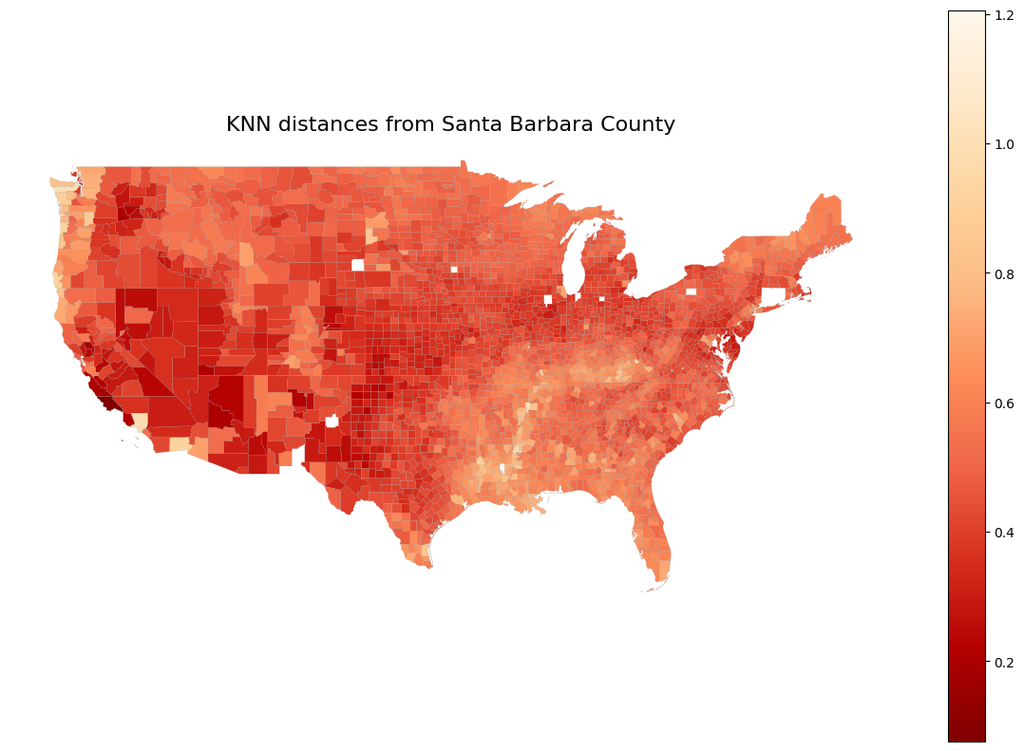

```python
make_heat_map(county_name='Santa Barbara County', state_abbreviation='CA')
```

```
We will make a heat map for the county Los Angeles County, CA.
```

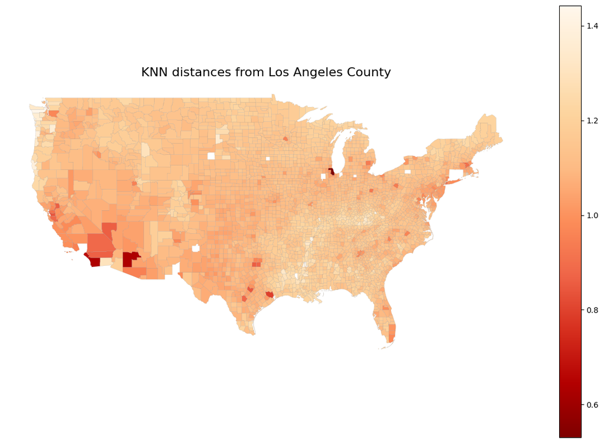

```python
make_heat_map(FIPS_code='06037')
```

The first thing we notice is that a lot more counties are colored for the Santa Barbara heat map. This suggests that a lot more counties are similar to Santa Barbara County compared to LA county. This implies that LA County has more unique features than Santa Barbara County, which makes sense.

The other thing to note is that the darker counties in the LA heat map are the ones with other big cities. For example, the counties with Chicago, San Diego, Phoenix, and Houston are all lit up.

# Conclusion

In the future, there are some improvements that can be made to these models that may help improve their functionality. Some examples of potential improvements are:

- Increase the number of columns to give the model more data to understand the ways in which two counties are similar
- Perform more testing and parameter tuning to increase the effectiveness of the KNN model
- Figure out a way to streamline the survey process to increase ease of use

Overall, our two models have proven that they are able to successfully fulfill their use cases. They were able to understand what the user was looking for in a place to live and provide relevant recommendations. We were able to satisfy our project goal, which was to create a tool that helps aid a user in their search for a new home.